# Differential Expression and Visualization in R

Taylor Reiter

N. Tessa Pierce

## Learning objectives:

- Create a gene-level count matrix of Salmon quantification using tximport
- Perform differential expression of a single factor experiment in DESeq2
- Perform quality control and exploratory visualization of RNA-seq data in R

## Tximeta

We first need to read our data into R. To do that, we will use a package called [tximeta](https://bioconductor.org/packages/release/bioc/html/tximeta.html). We use tximeta for two main reasons: first, it facilitates summarizing transcript-level counts from Salmon to the gene-level for differential expression analysis. Second, tximeta enhances incorporates metadata (e.g. transcript locations, transcript and genome source and version, appropriate chromosome lengths, etc) for each transcriptome. This ensures computational reproducibility by attaching critical annotation information to the data object, such that exact quantifications can be reproduced from raw data (all software versions are also attached to the data object).

For more information, see the [tximeta vignette](https://bioconductor.org/packages/release/bioc/vignettes/tximeta/inst/doc/tximeta.html)

Since we’re working in binder, all of the software is already installed. If you’d like to do a similar analysis on your own system, you can use the following installation commands:

```r
install.packages("ggplot2")
install.packages("dplyr")
install.packages("readr")
install.packages("pheatmap")
#install.packages("RSQlite")
install.packages("data.table")
install.packages("kableExtra")

if (!requireNamespace("BiocManager", quietly = TRUE))
 install.packages("BiocManager", version = "3.11")
BiocManager::install("tximeta")
BiocManager::install("DESeq2")
BiocManager::install("SummarizedExperiment")
```

```r
library(SummarizedExperiment)
library(tximeta)
library(DESeq2)
library(dplyr)
```

```r
library(ggplot2)
library(readr)
library(pheatmap)
```

This lesson is executed in binder, so the relevant paths should work if we’re running this from within the 2020-ggg-201b-rnaseq folder.

First let’s read in our `rnaseq_samples.csv` file. This file designates the names of our samples, their conditions, and the path to their quantification files.

```r
samples <- read_csv("rnaseq_samples.csv")
```

| names | files | condition |
| --- | --- | --- |
| ERR458493 | rnaseq/quant/ERR458493_quant/quant.sf | wt |
| ERR458494 | rnaseq/quant/ERR458494_quant/quant.sf | wt |
| ERR458495 | rnaseq/quant/ERR458495_quant/quant.sf | wt |
| ERR458496 | rnaseq/quant/ERR458496_quant/quant.sf | wt |
| ERR458500 | rnaseq/quant/ERR458500_quant/quant.sf | snf2 |
| ERR458501 | rnaseq/quant/ERR458501_quant/quant.sf | snf2 |
| ERR458502 | rnaseq/quant/ERR458502_quant/quant.sf | snf2 |
| ERR458503 | rnaseq/quant/ERR458503_quant/quant.sf | snf2 |

Next we need to define our reference files. We will use ensembl files, as this simplifies the way we interact with this information.

```r
indexDir <- file.path("rnaseq", "quant", "sc_ensembl_index")
fastaFTP <- c("ftp://ftp.ensembl.org/pub/release-99/fasta/saccharomyces_cerevisiae/cdna/Saccharomyces_cerevisiae.R64-1-1.cdna.all.fa.gz")
gtfPath <- "ftp://ftp.ensembl.org/pub/release-99/gtf/saccharomyces_cerevisiae/Saccharomyces_cerevisiae.R64-1-1.99.gtf.gz"
gtfLocal <- "yeast_ref/Saccharomyces_cerevisiae.R64-1-1.99.gtf.gz"
fastaLocal <- "yeast_ref/Saccharomyces_cerevisiae.R64-1-1.cdna.all.fa.gz"
```

With this information set, we can now build an object that saves this information.

```r
makeLinkedTxome(indexDir = indexDir,
                source   = "Ensembl",
                organism = "Saccharomyces cerevisiae",
                release  = "99",
                genome   = "GCA_000146045.2",
                fasta    = fastaLocal,
                gtf      = gtfLocal,
                write    = FALSE)
```

```
## NOTE: linkedTxome with source='Ensembl', ensembldb will be used to parse GTF.
## this may produce errors if the GTF is not from Ensembl, or has been modified.
## set useHub=FALSE in tximeta to avoid download of reference txome from AnnotationHub.
## alternatively use a different string for source argument
```

```
## saving linkedTxome in bfc (first time)
```

To create an `se` object for using our `tximeta` information:

```r
se <- tximeta(samples)
```

```
## importing quantifications
```

```
## reading in files with read_tsv
```

```
## 1 2 3 4 5 6 7 8
## found matching linked transcriptome:
## [ Ensembl - Saccharomyces cerevisiae - release 99 ]
## useHub=TRUE: checking for EnsDb via 'AnnotationHub'
## found matching EnsDb via 'AnnotationHub'
## loading from cache
## require("ensembldb")
## generating transcript ranges
```

To look at our `se` object, we can use the following commands:

```r
colData(se)
assayNames(se)
rowRanges(se)
seqinfo(se)
```

And to summarize to gene level, we can use `summarizeToGene()`.

```r
gse <- summarizeToGene(se)
```

```
## loading existing EnsDb created: 2026-03-16 19:06:38
```

```
## obtaining transcript-to-gene mapping from database
```

```
## generating gene ranges
```

```
## assignRanges='range': gene ranges assigned by total range of isoforms
##   see details at: ?summarizeToGene,SummarizedExperiment-method
```

```
## summarizing abundance
```

```
## summarizing counts
```

```
## summarizing length
```

And now let’s take a look at the data

```r
rowRanges(gse)
mcols(gse)
```

## Why do we need to normalize and transform read counts

Given a uniform sampling of a diverse transcript pool, the number of sequenced reads mapped to a gene depends on:

- its own expression level,
- its length,
- the sequencing depth,
- the expression of all other genes within the sample.

In order to compare the gene expression between two conditions, we must therefore calculate the fraction of the reads assigned to each gene relative to the total number of reads and with respect to the entire RNA repertoire which may vary drastically from sample to sample. While the number of sequenced reads is known, the total RNA library and its complexity is unknown and variation between samples may be due to contamination as well as biological reasons. **The purpose of normalization is to eliminate systematic effects that are not associated with the biological differences of interest.**

Normalization aims at correcting systematic technical biases in the data, in order to make read counts comparable across samples. The normalization proposed by DESeq2 relies on the hypothesis that most features are not differentially expressed. It computes a scaling factor for each sample. Normalized read counts are obtained by dividing raw read counts by the scaling factor associated with the sample they belong to.

## Differential Expression with `DESeq2`

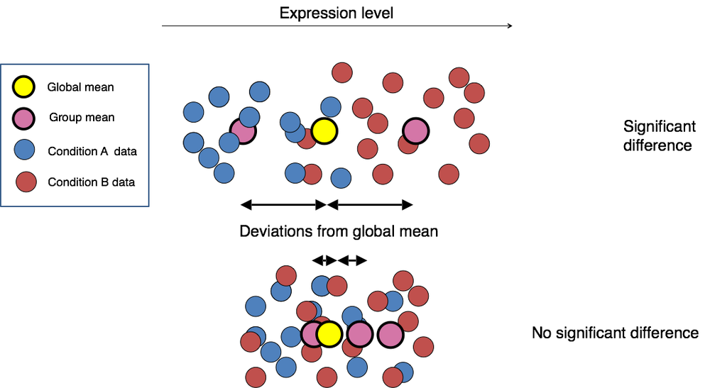

Image credit: Paul Pavlidis, UBC

Differential expression analysis with DESeq2 involves multiple steps as displayed in the flowchart below. Briefly,

- DESeq2 will model the raw counts, using normalization factors (size factors) to account for differences in library depth.
- Then, it will estimate the gene-wise dispersions and shrink these estimates to generate more accurate estimates of dispersion to model the counts.
- Finally, DESeq2 will fit the negative binomial model and perform hypothesis testing using the Wald test or Likelihood Ratio Test.

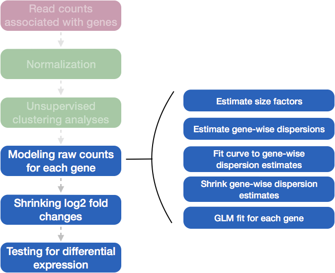

We’re now ready to use `DESeq2`, the package that will perform differential expression.

```r
dds <- DESeqDataSet(se = gse, design = ~condition)
```

```
## using counts and average transcript lengths from tximeta
```

```
## Warning in DESeqDataSet(se = gse, design = ~condition): some variables in
## design formula are characters, converting to factors
```

Note: DESeq stores virtually all information associated with your experiment in one specific R object, called DESeqDataSet. This is, in fact, a specialized object of the class “SummarizedExperiment”. This, in turn,is a container where rows (rowRanges()) represent features of interest (e.g. genes, transcripts, exons) and columns represent samples (colData()). The actual count data is stored in theassay()slot.

The first thing we notice is that both our counts and average transcript length were used to construct the `DESeq` object. We also see a warning message, where our condition was converted to a factor. Both of these messages are ok to see!

Now that we have a DESeq2 object, we can can perform differential expression.

```r
dds <- DESeq(dds)
```

```
## using 'avgTxLength' from assays(dds), correcting for library size
```

Everything from normalization to linear modeling was carried out by the use of a single function! This function prints out a message for the various steps it performs.

And look at the results! The results() function lets you extract the base means across samples, log2-fold changes, standard errors, test statistics etc. for every gene.

```r
res <- results(dds)
```

```r
head(res)
```

|  | baseMean | log2FoldChange | lfcSE | stat | pvalue | padj |
| --- | --- | --- | --- | --- | --- | --- |
| Q0010 | 0.0000000 | NA | NA | NA | NA | NA |
| Q0017 | 0.0000000 | NA | NA | NA | NA | NA |
| Q0032 | 0.0000000 | NA | NA | NA | NA | NA |
| Q0045 | 0.1580260 | -0.0590315 | 3.065534 | -0.0192565 | 0.9846365 | NA |
| Q0050 | 0.4448083 | 0.1225434 | 1.938986 | 0.0631997 | 0.9496075 | 0.971625 |
| Q0055 | 0.0750522 | 0.6718831 | 3.533812 | 0.1901298 | 0.8492074 | NA |

Speaking of log2fold change, what do all of these columns mean?

| baseMean | giving means across all samples |
| --- | --- |
| log2FoldChange | log2 fold changes of gene expression from one condition to another. Reflects how different the expression of a gene in one condition is from the expression of the same gene in another condition. |
| lfcSE | standard errors (used to calculate p value) |
| stat | test statistics used to calculate p value) |
| pvalue | p-values for the log fold change |
| padj | adjusted p-values |

We see that the default differential expression output is sorted the same way as our input counts. Instead, it can be helpful to sort and filter by adjusted p value or log2 Fold Change:

```r
res_sig <- subset(res, padj<0.1)
res_lfc <- subset(res_sig, abs(log2FoldChange) > 1)
```

```r
head(res_lfc)
```

|  | baseMean | log2FoldChange | lfcSE | stat | pvalue | padj |
| --- | --- | --- | --- | --- | --- | --- |
| YAL003W | 1052.802880 | 1.272206 | 0.0442574 | 28.745613 | 0.0000000 | 0.0000000 |
| YAL005C | 1809.219554 | 1.814659 | 0.0356372 | 50.920382 | 0.0000000 | 0.0000000 |
| YAL019W-A | 18.086767 | 1.320352 | 0.3654464 | 3.612984 | 0.0003027 | 0.0013938 |
| YAL026C-A | 14.923721 | -1.129194 | 0.4046203 | -2.790750 | 0.0052586 | 0.0175806 |
| YAL031W-A | 9.280742 | -1.324920 | 0.5087410 | -2.604311 | 0.0092059 | 0.0285153 |
| YAL037W | 6.708665 | -1.575729 | 0.6251046 | -2.520744 | 0.0117107 | 0.0350544 |

## Visualization of RNA-seq and Differential Expression Results

Looking at our results is great, but visualizing them is even better!

### MA Plot

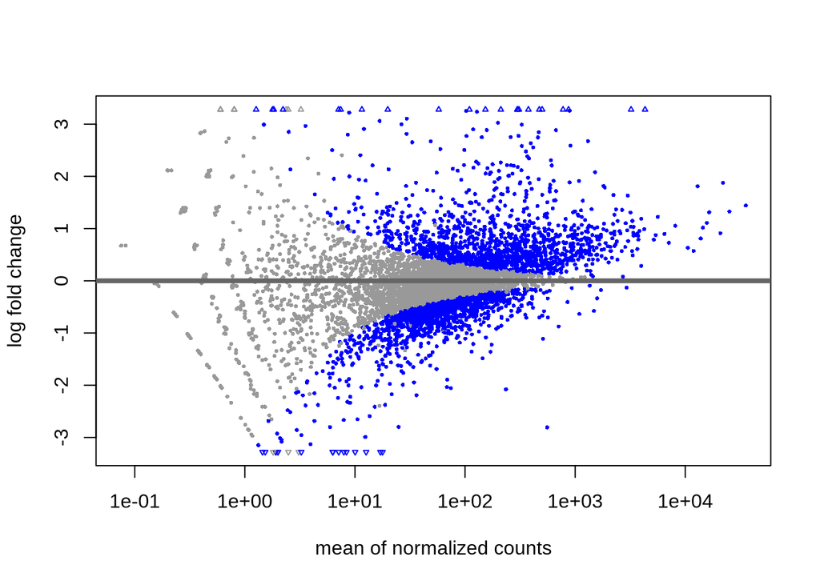

```r
plotMA(res)
```

**Question**  
Why are more genes grey on the left side of the axis than on the right side?

### Plotting individual genes

Although it’s helpful to plot many (or all) genes at once, sometimes we want to see how counts change for a specific gene. We can use the following code to produce such a plot:

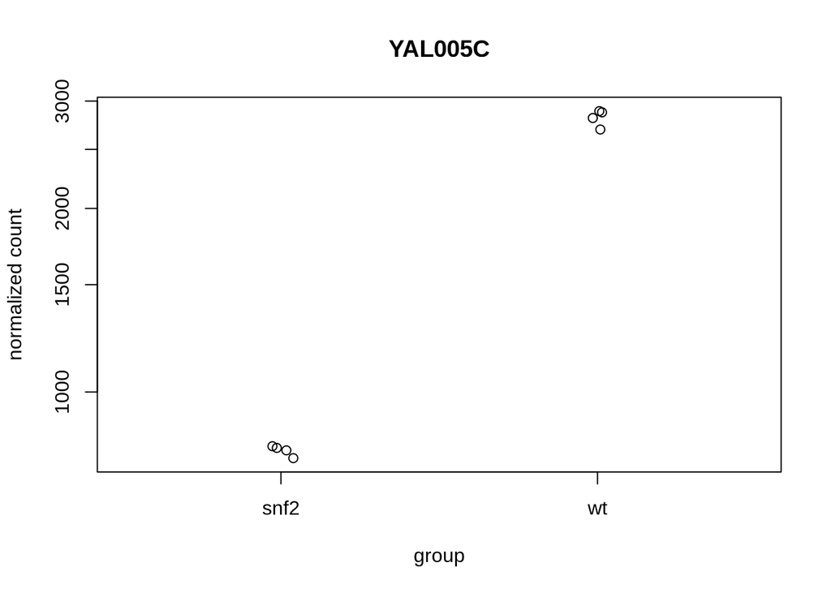

```r
plotCounts(dds, gene=which.min(res$padj), intgroup="condition")
```

**Question**  
What gene is plotted here (i.e., what criteria did we use to select a single gene to plot)?

### Normalization & Transformation

`DESeq2` automatically normalizes our count data when it runs differential expression. However, for certain plots, we need to normalize our raw count data. One way to do that is to use the `vst()` function. It perform variance stabilized transformation on the count data, while controlling for library size of samples.

```r
vsd <- vst(dds)
```

### MDS Plot

An MDS (multi-dimensional scaling) plot gives us an idea of how our samples relate to each other. The closer two samples are on a plot, the more similar all of their counts are. To generate this plot in DESeq2, we need to calculate “sample distances” and then plot them.

```r
# calculate sample distances
sample_dists <- assay(vsd) %>%
  t() %>%
  dist() %>%
  as.matrix()
```

```r
head(sample_dists)
```

|  | ERR458493 | ERR458494 | ERR458495 | ERR458496 | ERR458500 | ERR458501 | ERR458502 | ERR458503 |
| --- | --- | --- | --- | --- | --- | --- | --- | --- |
| ERR458493 | 0.00000 | 27.51114 | 27.35791 | 26.88236 | 46.02258 | 46.23133 | 46.34819 | 46.85409 |
| ERR458494 | 27.51114 | 0.00000 | 26.43968 | 26.52014 | 45.84812 | 45.67315 | 45.75645 | 45.78417 |
| ERR458495 | 27.35791 | 26.43968 | 0.00000 | 27.47391 | 45.93991 | 46.05857 | 46.23837 | 46.30268 |
| ERR458496 | 26.88236 | 26.52014 | 27.47391 | 0.00000 | 46.07861 | 45.91085 | 46.26999 | 46.00680 |
| ERR458500 | 46.02258 | 45.84812 | 45.93991 | 46.07861 | 0.00000 | 17.24574 | 18.05325 | 18.34467 |
| ERR458501 | 46.23133 | 45.67315 | 46.05857 | 45.91085 | 17.24574 | 0.00000 | 17.62063 | 17.72767 |

Next, let’s calculate the MDS values from the distance matrix.

```r
mdsData <- data.frame(cmdscale(sample_dists))
mds <- cbind(mdsData, as.data.frame(colData(vsd))) # combine with sample data
```

```r
head(mds)
```

|  | X1 | X2 | names | condition |
| --- | --- | --- | --- | --- |
| ERR458493 | -21.03020 | 13.5291556 | ERR458493 | wt |
| ERR458494 | -20.51526 | -8.6072336 | ERR458494 | wt |
| ERR458495 | -20.82645 | -10.1971266 | ERR458495 | wt |
| ERR458496 | -20.81452 | 5.1411897 | ERR458496 | wt |
| ERR458500 | 20.65666 | 0.7276064 | ERR458500 | snf2 |
| ERR458501 | 20.77288 | 0.2551090 | ERR458501 | snf2 |

And plot with `ggplot2`!

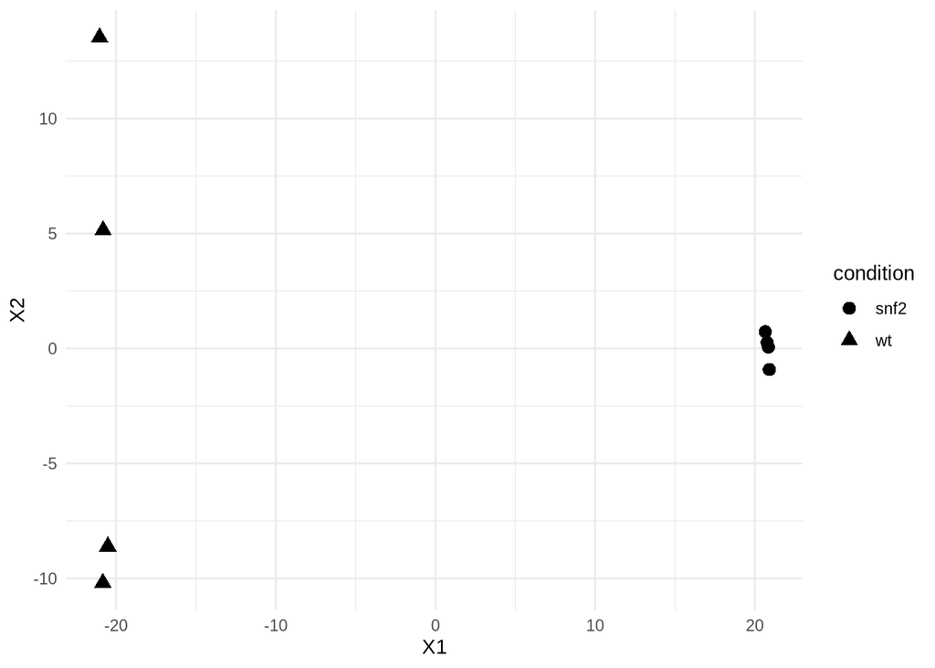

```r
ggplot(mds, aes(X1, X2, shape = condition)) +
  geom_point(size = 3) +
  theme_minimal()
```

**Question**  
How similar are the samples between conditions?

### Heatmap

```r
genes <- order(res_lfc$log2FoldChange, decreasing=TRUE)[1:20]
```

We can also make a data.frame that contains information about our samples that will appear in the heatmap. We will use our samples data.frame from before to do this.

```r
annot_col <- samples %>%
        tibble::column_to_rownames('names') %>%
        dplyr::select(condition) %>%
        as.data.frame()
```

```r
head(annot_col)
```

|  | condition |
| --- | --- |
| ERR458493 | wt |
| ERR458494 | wt |
| ERR458495 | wt |
| ERR458496 | wt |
| ERR458500 | snf2 |
| ERR458501 | snf2 |

And now plot the heatmap!

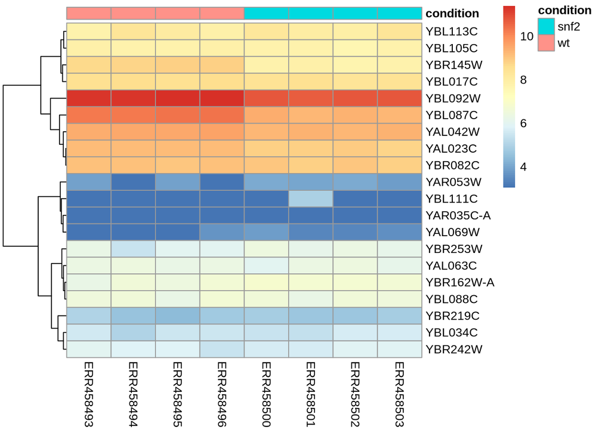

```r
pheatmap(assay(vsd)[genes, ], cluster_rows=TRUE, show_rownames=TRUE,
         cluster_cols=FALSE, annotation_col=annot_col)
```

**Question**  
When are heatmaps useful?  
What other types of heatmaps have you seen in the wild?

## Further Notes

Here are some helpful notes or resources for anyone performing differential expression.

- Introduction to differential gene expression analysis using RNA-seq (Written by Friederike Dündar, Luce Skrabanek, Paul Zumbo). Click [here](http://chagall.med.cornell.edu/RNASEQcourse/Intro2RNAseq.pdf)
- Introduction to DGE - click [here](https://hbctraining.github.io/DGE_workshop/lessons/04_DGE_DESeq2_analysis.html)